# Soil parameters

Christian Sommer

## Soil data

We start by importing the results of a soil texture analysis from a table. The table contains a row for each layer with the following columns:

- Name
- lab number
- thickness in [cm]
- texture in [%]
- organic matter in [%]
- comment

```r
d <- read.csv("../data/soil_profile.csv", sep=";")
```

|  | name | labno | thickness | clay | csilt | fsilt | csand | msand | fsand | vfsand | som | comment |
| --- | --- | --- | --- | --- | --- | --- | --- | --- | --- | --- | --- | --- |
| 1 | Masotsheni 1 | FS51 | 50 | 36.98730 | 13.00652 | 19.10333 | 11.5700224 | 2.4227825 | 3.213895 | 13.6961376 | 4.8 | Topsoil |
| 2 | Masotsheni 2 | FS52 | 220 | 26.92769 | 20.03921 | 21.29166 | 21.3302412 | 4.6215523 | 5.383347 | 0.4062903 | 3.2 | Paleosols |
| 3 | Masotsheni 3 | FS53 | 70 | 56.47385 | 10.34635 | 20.90826 | 0.8390795 | 0.6293097 | 3.094106 | 7.7090433 | 1.2 | Tansitional layer |
| 4 | Masotsheni 4 | FS54 | 250 | 24.01935 | 15.30436 | 14.02900 | 35.5801914 | 5.4818318 | 5.016393 | 0.5688693 | 0.8 | Base layer |

Here’s the results in a USDA soil texture triangle

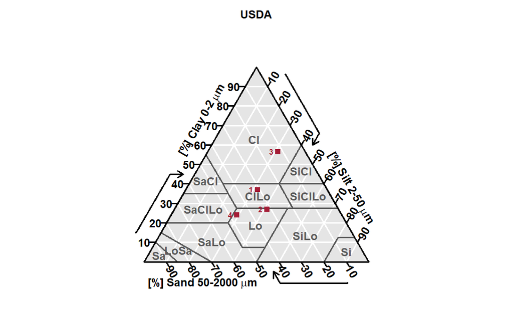

## Rill erodibility

Is calculated after Alberts et al. (1995) using the proportion of very fine sand $VFS$ [%] and the content of organic matter $OM$ [%] with the equation
$$\begin{equation}K_{r} = 0.00197 + 0.00030 VFS + 0.038633 \mathrm{e}^{-1.84OM}\end{equation}$$

```r
erodibility <- function(vfsand, om){
  0.00197+0.00030*vfsand+0.038633*exp(-1.84*om)
}
d$Kr <- erodibility(d$vfsand, d$som)
```

## Critical velocity

### Mean particle size diameter

We calculate the mean particle size diameter in [m] using the equation by Renard et al. (1997) with the primary fraction of the grain size classes $f_{i}$ in [%] and the arithmetic mean of the borders of the grain size classes $m_{i}$ in [mm].
$$\begin{equation} Dg = exp(0.01 \sum{} f_{i}\cdot ln \cdot m_{i})\end{equation}$$

```r
mean_particle_diameter <- function(clay=0, silt=0, sand=0, csilt=0, fsilt=0, csand=0, msand=0, fsand=0, vfsand=0, method="geometric", classification="USDA"){
  if(classification=="USDA"){
    gsize <- c(mean(c(0, 0.002)),    # Clay
               mean(c(0.002, 0.05)), # Silt
               mean(c(0.05, 2)),   # Sand
               mean(c(0.05, 0.02)),  # Coarse silt
               mean(c(0.02, 0.002)), # Fine silt
               mean(c(2, 0.5)),      # Coarse sand
               mean(c(0.5, 0.25)),   # Medium sand
               mean(c(0.25, 0.1)),   # Fine sand
               mean(c(0.1, 0.05)))   # Very fine sand
  }
  if(method=="geometric"){
    mean_diameter <- exp(0.01 * (
        clay * log(gsize[1]) +
        silt * log(gsize[2]) +
        sand * log(gsize[3]) +
        csilt * log(gsize[4]) +
        fsilt * log(gsize[5]) +
        csand * log(gsize[6]) +
        msand * log(gsize[7]) +
        fsand * log(gsize[8]) +
        vfsand * log(gsize[9])
    ))
  }
  return(mean_diameter/1000) # from mm to m
}

d$Dg <- mean_particle_diameter(d$clay, d$csilt, d$fsilt, d$csand, d$msand, d$fsand, d$vfsand, method="geometric", classification="USDA")
```

### Shear stress

#### after Smeardon (1961)

$$\begin{equation} \tau_{c} = 3.11 \cdot 10^{0.0182C}\end{equation}$$

```r
shear_stress <- function(clay){
  shear_stress <- 3.11*10^(0.0182*clay) # in Pa (Pascal)
}

d$tau <- shear_stress(d$clay)
```

#### after Alberts et al. (1995)

$$\begin{equation} \tau_{c} = 2.67 + 0.065C - 0.058VFS\end{equation}$$

```r
shear_stress <- function(clay, vfsand){
  shear_stress <- 2.67 + 0.065 * clay - 0.058 * vfsand
}

d$tau <- shear_stress(d$clay, d$vfsand)
```

### Critical velocity

```r
v_crit <- function(m1=1,     # 1=clear water,...,1.4=colloidal suspended load > 0.1 kg/m3
                   n1=4,     # Turbulence: 4
                   ps,       # Density of soil kg/m3
                   p=1000,   # Density of water: ~1000 kg/m3
                   g=9.81,   # Newton/kg
                   d,        # mean particle size diameter (m)
                   K0=1,     # Soil mechanical coefficent: 0.5 (Maerker 2002) or 1 (Sidorchuk 2019)
                   Cnf       # Soil shear strength (Pa)
){
  # Critical velocity of bed erosion initiation (after 1pers. comm. Sidorchuck 2019)
  v_crit <- 1.25 * sqrt(
    (2*m1/1.54*p*n1)*
      ((ps-p)*g*d + 1.25*Cnf*K0)
  )
  return(v_crit)
}

d$v_crit <- v_crit(ps=2500, d=d$Dg, Cnf=d$tau)
```

## Critical slope

The critical slope is simply the slope measured in the field or obtained from a high-res DEM coverted to radians.

```r
s_crit <- function(slope, unit="degrees"){
  if(unit=="degrees"){
    s_crit <- slope*pi/180
  }else if(unit=="percent"){
    s_crit <- atan(slope/100)
  }
}
# Since all layers have the same slope in this example, we can assign the same value. Otherwise get the value from the table.
d$s_crit <- s_crit(57, "degrees")
```

## Export

Now we can export all relevant variables of each layer to an individual PARAM.txt parameter file.

```r
layer_export <- function(years, lnumber=1, v_crit, s_crit, Kr, Qdat="S_150.txt"){
  for (i in seq(1,lnumber)){
    filename <- paste("../output/PARAM", toString(i), ".txt", sep="")
    Layer <- file(filename, open="w")
    lines <- c("0\t0",
               i,              # Number of layer
               v_crit[i],      # Critical Velocity
               "0",            # Index of texture layer (unused)
               s_crit[i],      # Stable slope
               Kr[i],          # Erodibility coefficent
               "S_150.txt",
               years,
               seq(1, years, 1))
    writeLines(lines, con=Layer)
    close(Layer)
    rm(i, filename, Layer, lines)
}}


# Apply
layer_export(years=59, lnumber=nrow(d), v_crit=d$v_crit, s_crit=d$s_crit, Kr=d$Kr)
```

## References

Bogomolov, A. I. and K. A. Mikhaylov (1972). Hydravlica. Moscow, Stroyizdat. Alberts, E. E., Nearing, M. A., Weltz, M. A., Risse, L. M., Pierson, F. B., Zhang, X. C., Laflen, J. M., and Simanton, J. R. (1995). Soil Component, Tech. Rep. July, USDA.